fossil

# Missing covariates in Cox models, dug back up.

29 results: 4 exact, 13 agree, 9 partly agree, 1 differ, 2 not attempted. The lost simulation was rebuilt from the paper as an R package and run again, and every plotted point was read back out of the paper's own figures.

See every result

## Install misscox

R package

```
remotes::install_github("jeonglab-bcm/fossil/PMC2824146/package")
```

It needs R 4.3 or later and the CRAN packages survival, mice, Hmisc, norm and mix (TH.data for the breast cancer data).

[README](https://github.com/jeonglab-bcm/fossil/blob/main/PMC2824146/package/README.md) [Tutorial](https://github.com/jeonglab-bcm/fossil/blob/main/PMC2824146/package/tutorial/TUTORIAL.md)

## Fig. 1

Fig. 1. Histograms of the covariates of the breast cancer data (a) and of the transformed continuous covariates (b). Ours from TH.data::GBSG2 with R's default breaks.

Agrees

Published

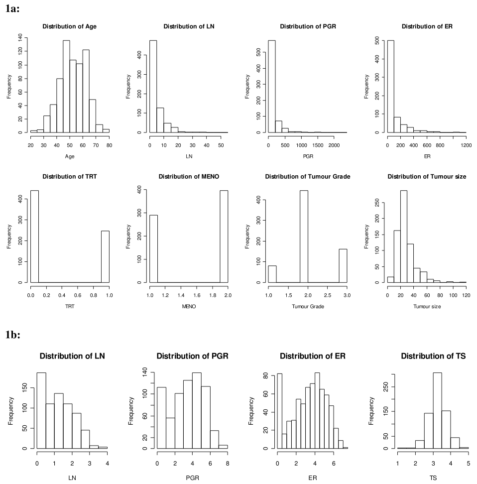

Our run

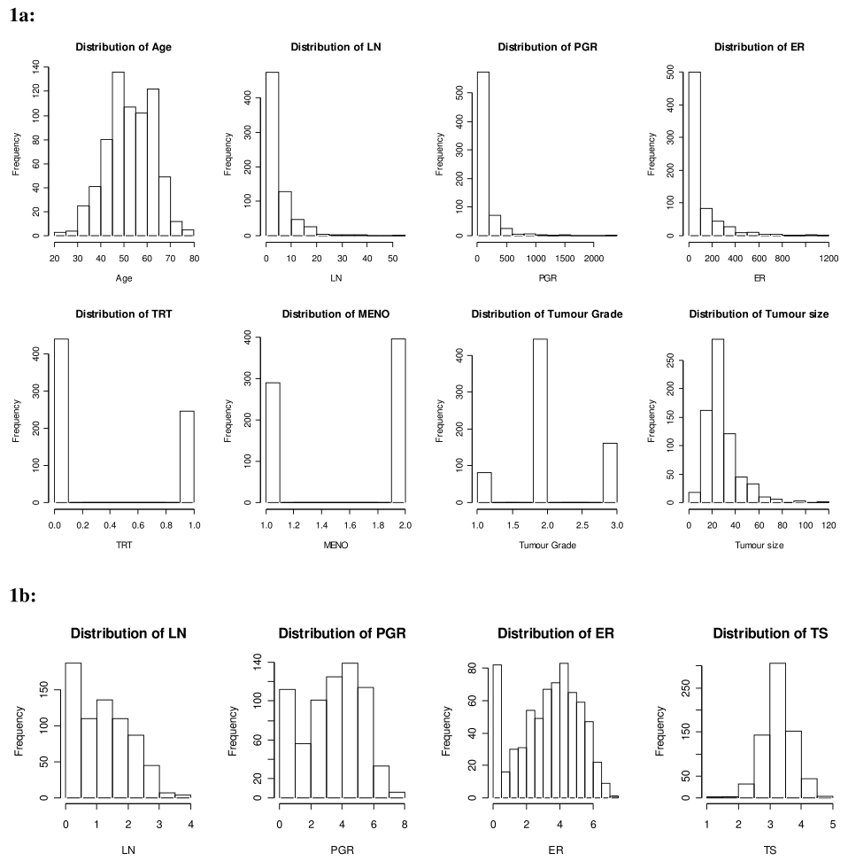

**Fig. 1, histograms of the covariates (a) and the transformed covariates (b)**

82 of 82 values, Agrees

## Fig. 2

Fig. 2. Average coefficient estimates by method and amount of MAR missingness; dashed lines: true value and 0.5 SE either side.

Agrees

Published

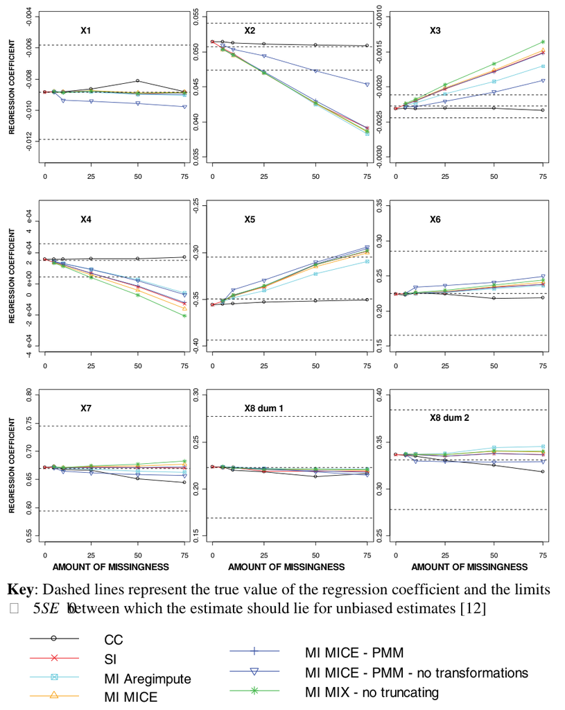

Our run

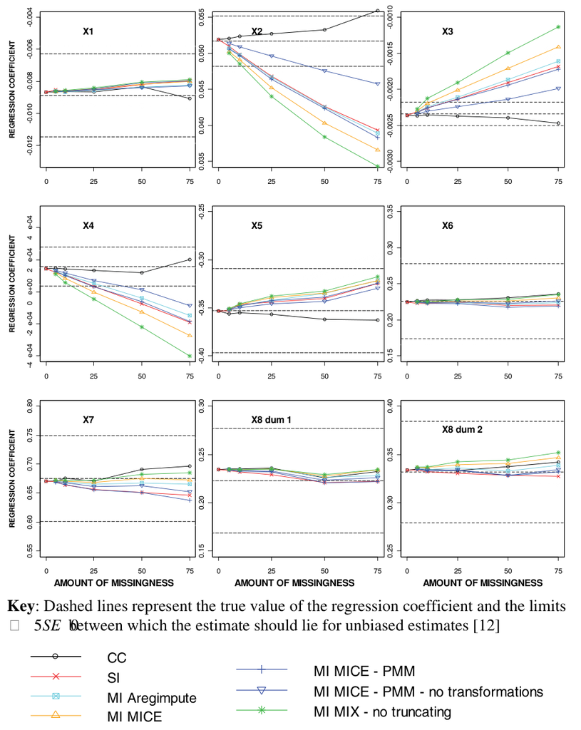

**Fig. 2, coefficient estimates under MAR**

301 of 333 values, Agrees

Most points fall within Monte Carlo error. Most of the 32 misses are estimates of X2, X3, X4 and X5 at 50 and 75% (five at 25%), mostly MI and SI, where our MIX without truncating, MICE-PMM and SI are further from or nearer the truth than the paper's. The offset of the true values does not explain them; the 2004 to 2005 package versions could not be tested.

## Fig. 3

Fig. 3. Average SE by method and amount of MAR missingness; dashed line: empirical SE with no missing data.

Partly agrees

Published

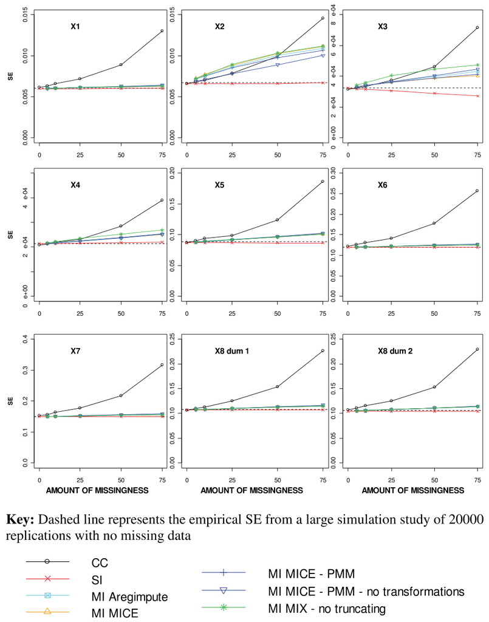

Our run

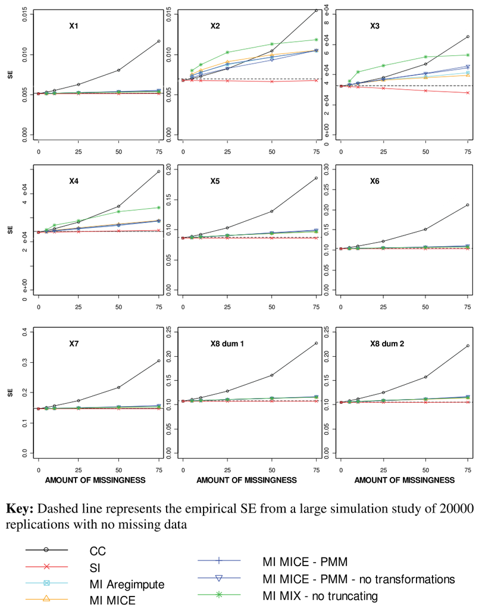

**Fig. 3, average SEs under MAR**

164 of 333 values, Partly agrees

Every point of X1, X4 and X6 misses by a near-constant factor across methods and levels (ours 0.83 to 0.91, 1.12 to 1.29 and 0.83 to 0.87 times the paper's, medians 0.86, 1.14 and 0.86), close to the ratio of their empirical SEs with no missing data (0.86, 1.14, 0.87): the generated covariates differ (see the reference lines). Keeping the binaries' correlations moves the X1 and X6 SEs past the paper's. The other misses (X2, X5) are MI SEs at 50 and 75%.

## Fig. 4

Fig. 4. Coverage of the true value by the 95% interval under MAR; dashed lines: 80, 90 and 95%.

Agrees

Published

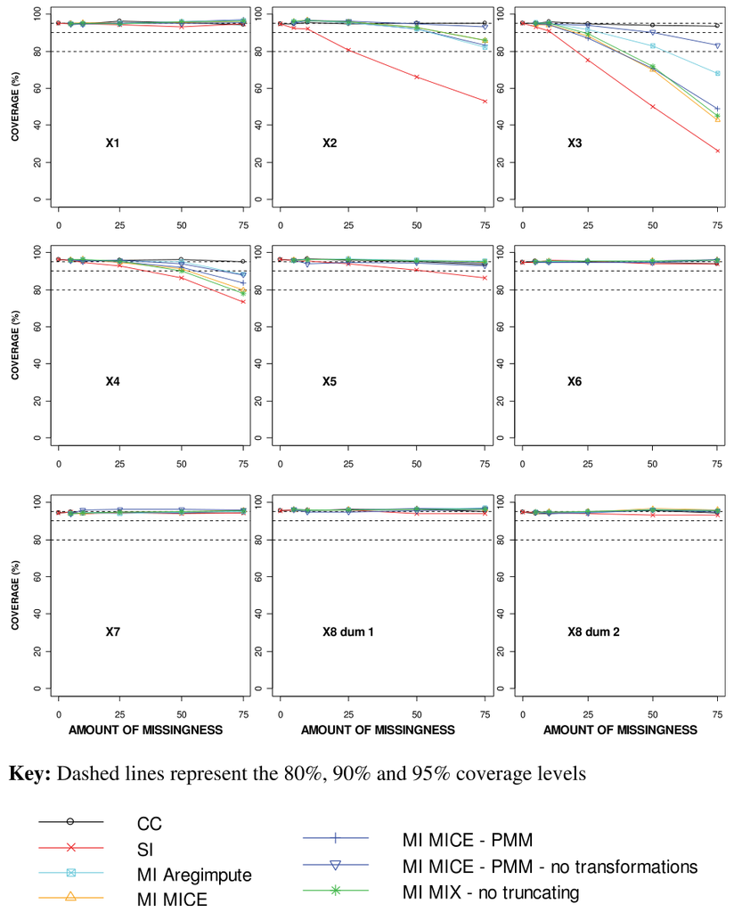

Our run

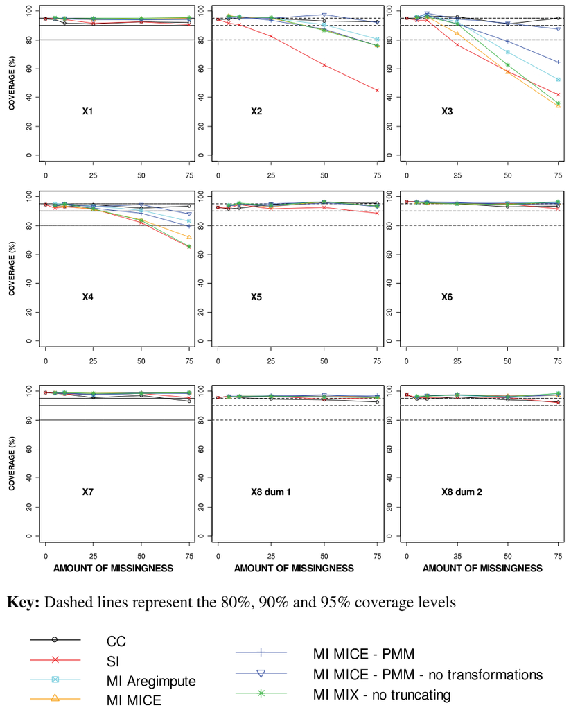

**Fig. 4, coverage under MAR**

322 of 333 values, Agrees

## Fig. 5

Fig. 5. Mean Wald p-value of each covariate under MAR; dashed line: 0.05.

Agrees

Published

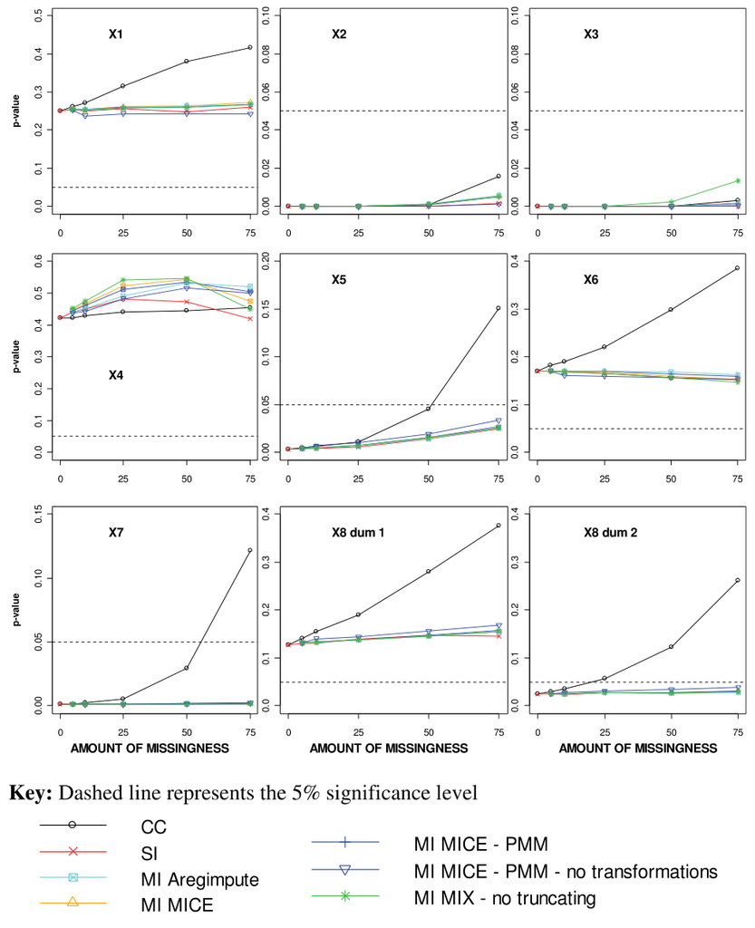

Our run

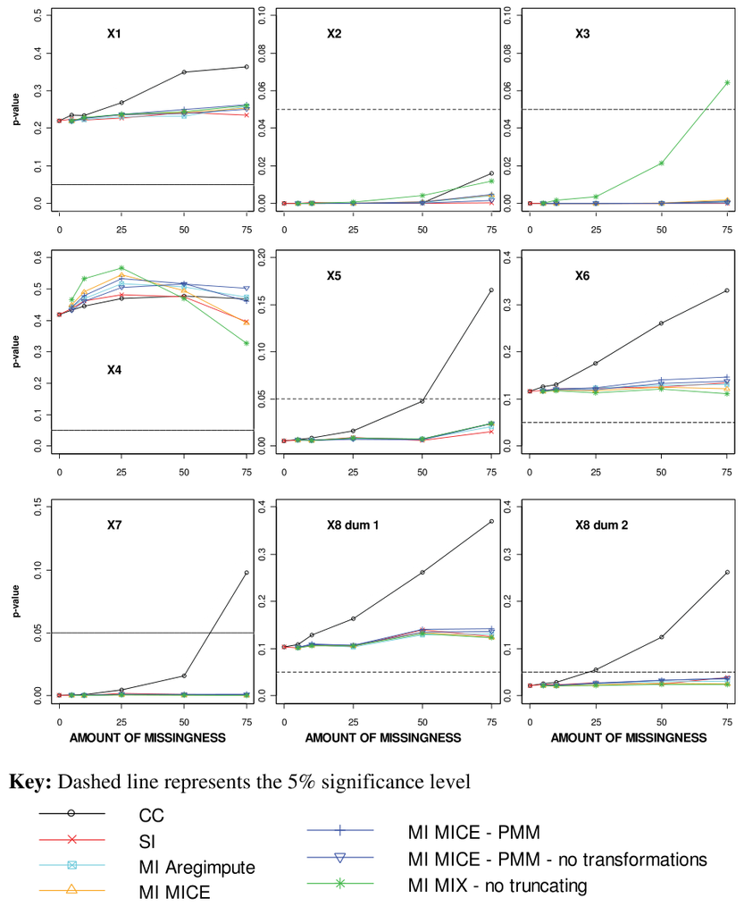

**Fig. 5, mean p-values under MAR**

295 of 333 values, Agrees

Most misses are X6, whose mean p-value is lower in our run at every level and method, as its SE is about 14% smaller (Fig. 3); the rest are scattered MI points for X2 to X5.

## Fig. 6

Fig. 6. Model performance under MAR: (a) mean p-value of the likelihood ratio test, (b) Nagelkerke R2, (c) D statistic, (d) predicted 2-year survival.

Agrees

Published

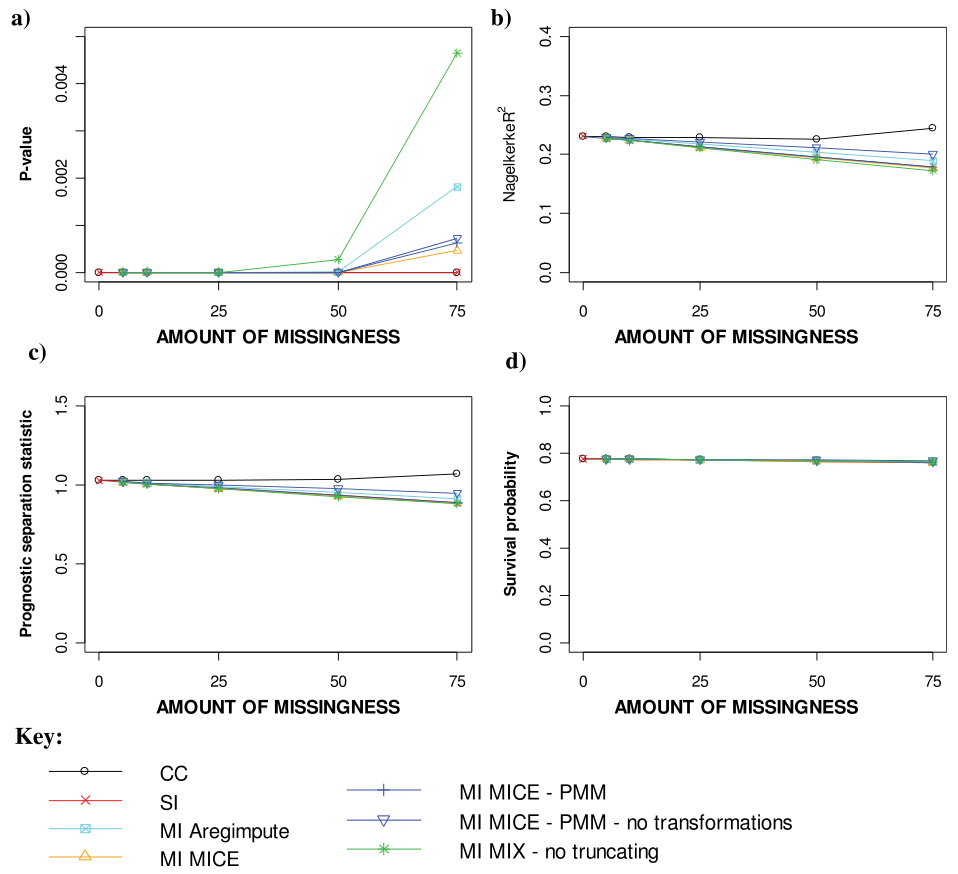

Our run

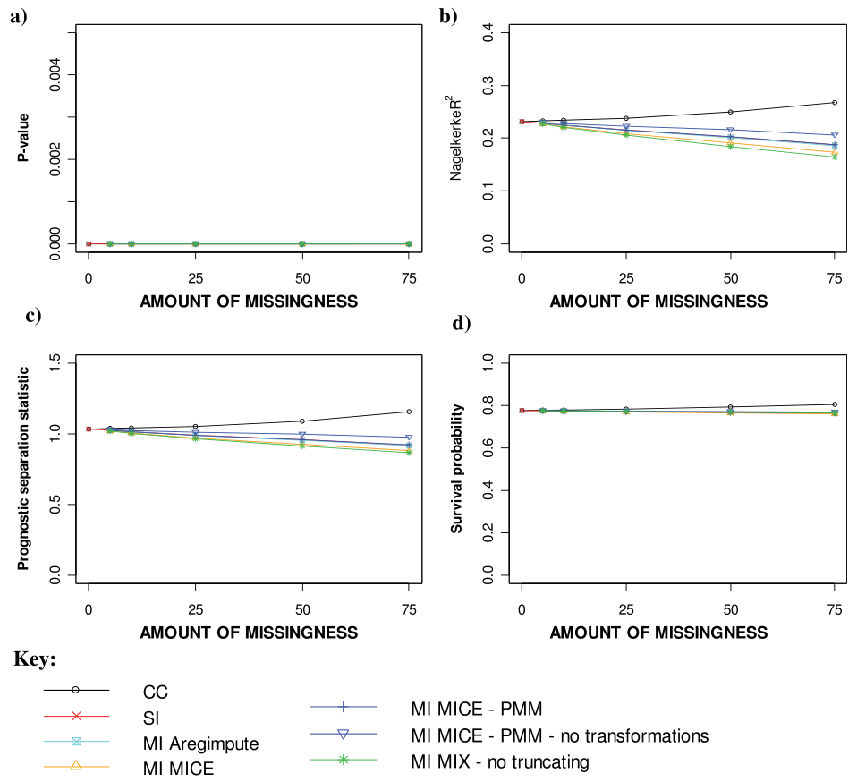

**Fig. 6, model performance under MAR (LR p, R2, D, 2-year survival)**

125 of 148 values, Agrees

Two gaps. The pooled likelihood ratio p-values after MI are below 3 x 10^-6 in our run against up to 0.0046 in the paper; no pooling rule we tried gives the paper's values. Complete-case R2, D and 2-year survival rise with missingness in our run (2-year survival 0.805 at 75% against 0.760): reversing X5's time term brings survival to 0.771 but leaves R2 and D high.

## Fig. 7

Fig. 7. Coefficient estimates of X2 to X5 for four MI methods under MAR and MNAR.

Agrees

Published

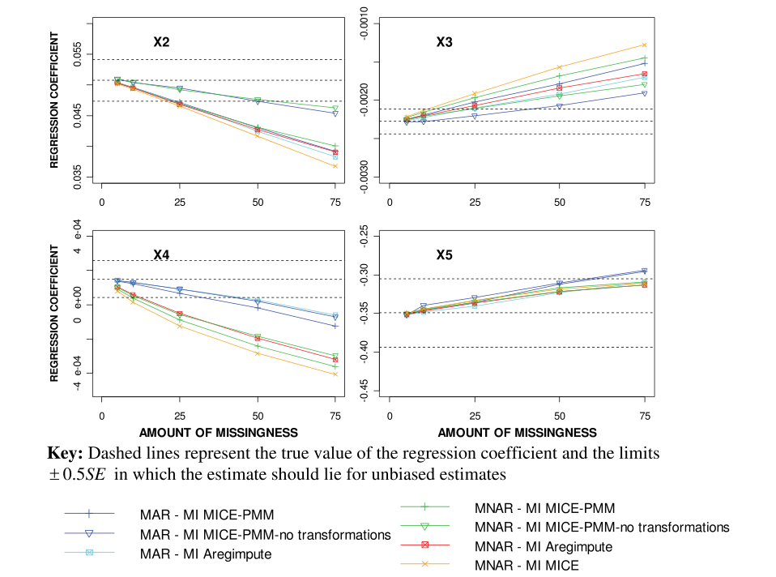

Our run

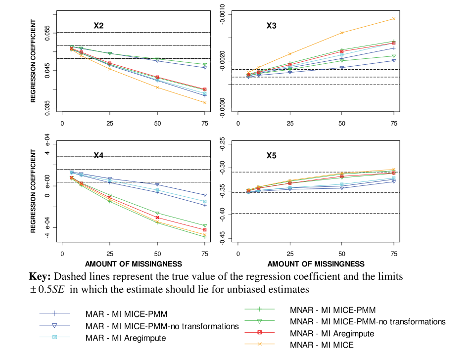

**Fig. 7, coefficients of X2 to X5 under MAR and MNAR**

119 of 140 values, Agrees

The MAR series match as in Fig. 2. Under MNAR our X4 estimates (every MI method shown) and X3 with MICE are further from the truth than the paper's at 50 and 75% (X4 with MICE-PMM at 75%: -0.00049 against -0.00036); X3 with MICE-PMM is nearer. The scale of X3's own term does not explain it.

## Fig. 8

Fig. 8. Coverage of X2 to X4 for four MI methods under MAR and MNAR.

Agrees

Published

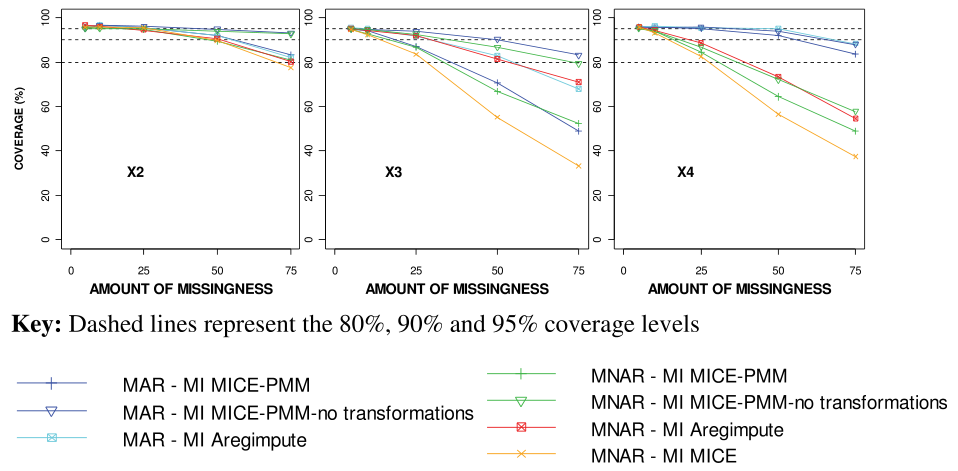

Our run

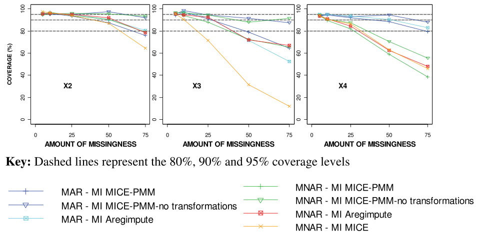

**Fig. 8, coverage of X2 to X4 under MAR and MNAR**

94 of 105 values, Agrees

## Every result

Every figure, table and claim of the paper. A figure point agrees when it is within 3 combined Monte Carlo standard errors and one PDF grid step of the published one; long lists show only the points that miss.

Result

Verdict

Measure

Why

Table 1, means and SDs after transformation

Exact

16 of 16 values

- X1 mean: paper 53.05, ours **53.0525**
- X1 SD: paper 10.12, ours **10.1207**
- X2 mean: paper 1.16, ours **1.16087**
- X2 SD: paper 0.94, ours **0.938642**
- X3 mean: paper 3.35, ours **3.34947**
- X3 SD: paper 1.93, ours **1.93127**
- X4 mean: paper 3.35, ours **3.35093**
- X4 SD: paper 1.84, ours **1.84479**
- X5 mean: paper 0.36, ours **0.358601**
- X5 SD: paper 0.48, ours **0.47994**
- X6 mean: paper 0.58, ours **0.577259**
- X6 SD: paper 0.49, ours **0.494355**
- X7 mean: paper 0.88, ours **0.881924**
- X7 SD: paper 0.32, ours **0.322933**
- X8 mean: paper 3.27, ours **3.27457**
- X8 SD: paper 0.46, ours **0.458837**

Skewness of X2, X3, X4, X8 (Methods text)

Agrees

4 of 4 values

- X2 skewness: paper 2.87, ours **2.87216**
- X3 skewness: paper 4.77, ours **4.76541**
- X4 skewness: paper 3.07, ours **3.07427**
- X8 skewness: paper 1.77, ours **1.76802**

Correlations quoted in the Methods text

Agrees

4 of 4 values

- r(X1-X6): paper 0.77, ours **0.770076**
- r(X3-X4): paper 0.39, ours **0.392601**
- r(X2-X8): paper 0.33, ours **0.327665**
- r(X5-X6): paper 0.28, ours **0.276847**

Fig. 1, histograms of the covariates (a) and the transformed covariates (b)

Agrees

82 of 82 values

- 0 of 82 points outside their Monte Carlo tolerance

Linear predictor, full Cox model on the breast cancer data (Methods equation)

Exact

9 of 9 values

- X1: paper -0.0088, ours **-0.0088407**
- X2: paper 0.051, ours **0.0507193**
- X3: paper -0.0023, ours **-0.00227496**
- X4: paper 0.00015, ours **0.000149797**
- X5: paper -0.349, ours **-0.349231**
- X6: paper 0.225, ours **0.225344**
- X7: paper 0.67, ours **0.669674**
- X8d1: paper 0.223, ours **0.223028**
- X8d2: paper 0.331, ours **0.331079**

About 35% censored (Methods text)

Differs

0 of 1 values

- censored (%): paper 35, ours **36.4**

The text's 'approximately 35%' is a rounded figure: the stated hazards (0.0002 for censoring against 0.00027 exp(LP) for events) give 36.4% censored in our run and 36.6% with every variant of our generator.

Missingness design: incomplete cases, shares and overlaps (Methods text)

Partly agrees

22 of 40 values

- 18 of 40 points outside their Monte Carlo tolerance:
- incomplete cases at 5% (MCAR): paper 5, ours **5.278**
- incomplete cases at 10% (MCAR): paper 10, ours **10.49**
- X3 share of incomplete at 10% (MCAR): paper 70, ours **66.43**
- X2 share of incomplete at 10% (MCAR): paper 55, ours **52.26**
- both X2X3 share of incomplete at 10% (MCAR): paper 35, ours **32.85**
- both X8X3 share of incomplete at 10% (MCAR): paper 5, ours **4.222**
- incomplete cases at 25% (MCAR): paper 25, ours **25.75**
- X3 share of incomplete at 25% (MCAR): paper 70, ours **67.98**
- X2 share of incomplete at 25% (MCAR): paper 55, ours **53.08**
- both X2X3 share of incomplete at 25% (MCAR): paper 35, ours **33.98**
- incomplete cases at 50% (MCAR): paper 50, ours **50.76**
- X3 share of incomplete at 50% (MCAR): paper 70, ours **68.96**
- X2 share of incomplete at 50% (MCAR): paper 55, ours **54.12**
- both X2X3 share of incomplete at 50% (MCAR): paper 35, ours **34.34**
- incomplete cases at 75% (MCAR): paper 75, ours **73.93**
- X3 share of incomplete at 75% (MCAR): paper 70, ours **70.91**
- X2 share of incomplete at 75% (MCAR): paper 55, ours **56.11**
- both X2X3 share of incomplete at 75% (MCAR): paper 35, ours **35.64**

Table 2, specification of the missingness mechanisms

Not attempted

A design input, used as given (the blank X3 cell of the combined mechanism read as MCAR).

Table 3, odds ratios between missingness indicators

Agrees

15 of 15 values

- X2|MX3 at 5%: paper 101.12, ours **101.118**
- X2|MX3 at 10%: paper 45.5, ours **45.5**
- X2|MX3 at 25%: paper 15.68, ours **15.6782**
- X2|MX3 at 50%: paper 5.50, ours **5.5**
- X2|MX3 at 75%: paper 2.17, ours **2.17494**
- X5|MX2 at 5%: paper 42.04, ours **42.0435**
- X5|MX2 at 10%: paper 20.78, ours **20.7778**
- X5|MX2 at 25%: paper 7.41, ours **7.40708**
- X5|MX2 at 50%: paper 3.00, ours **3**
- X5|MX2 at 75%: paper 1.51, ours **1.51479**
- X8|MX3 at 5%: paper 45.14, ours **45.1406**
- X8|MX3 at 10%: paper 14.23, ours **14.2308**
- X8|MX3 at 25%: paper 5.44, ours **5.43673**
- X8|MX3 at 50%: paper 1.92, ours **1.92308**
- X8|MX3 at 75%: paper 0.92, ours **0.923692**

Table 4, the missing data methods

Not attempted

A list of methods and settings, implemented as given in the package.

Figs 2 and 3, reference lines: true values and empirical SEs (20,000 complete-data cohorts)

Partly agrees

10 of 18 values

- X1 true value: paper -0.0088378, ours **-0.00887994**
- X1 empirical SE: paper 0.00603606, ours **0.00517678**
- X2 true value: paper 0.0507289, ours **0.0516903**
- X2 empirical SE: paper 0.00671971, ours **0.00697148**
- X3 true value: paper -0.00227376, ours **-0.0023407**
- X3 empirical SE: paper 0.000324433, ours **0.000326045**
- X4 true value: paper 0.000150443, ours **0.000157845**
- X4 empirical SE: paper 0.000214005, ours **0.000243413**
- X5 true value: paper -0.349496, ours **-0.353**
- X5 empirical SE: paper 0.0885761, ours **0.0874814**
- X6 true value: paper 0.22488, ours **0.225689**
- X6 empirical SE: paper 0.119322, ours **0.103975**
- X7 true value: paper 0.669564, ours **0.674967**
- X7 empirical SE: paper 0.149842, ours **0.148086**
- X8d1 true value: paper 0.2228, ours **0.222783**
- X8d1 empirical SE: paper 0.10783, ours **0.10822**
- X8d2 true value: paper 0.33097, ours **0.331695**
- X8d2 empirical SE: paper 0.105975, ours **0.105245**

Our generator's empirical SEs are 14% smaller for X1 and X6 and 14% larger for X4 than the paper's, and its true values 1 to 5% larger in magnitude for X2, X3, X4 and X5 (X7 0.8%). Keeping the binaries' observed correlations takes the X1 and X6 SEs past the paper's (0.0064 and 0.132 against 0.0060 and 0.119, ours 0.0051 and 0.104); the unrounded coefficients move X2's true value from 0.0517 to 0.0513 (paper 0.0507); the X4 SE and the larger magnitudes stay open.

Fig. 2, coefficient estimates under MAR

Agrees

301 of 333 values

- 32 of 333 points outside their Monte Carlo tolerance; the first 24:
- X1 MICE-PMM no transformation 75%: paper -0.00976831, ours **-0.00828369**
- X2 CC 75%: paper 0.0508815, ours **0.0559152**
- X2 MICE 25%: paper 0.0469954, ours **0.0452355**
- X2 MICE 50%: paper 0.0426316, ours **0.0403246**
- X2 MICE 75%: paper 0.0385862, ours **0.0366093**
- X2 MIX no truncating 25%: paper 0.0469954, ours **0.0440186**
- X2 MIX no truncating 50%: paper 0.0427228, ours **0.0383956**
- X2 MIX no truncating 75%: paper 0.0386769, ours **0.034319**
- X3 SI 25%: paper -0.00203001, ours **-0.00213269**
- X3 SI 50%: paper -0.00177775, ours **-0.00190589**
- X3 SI 75%: paper -0.00151184, ours **-0.00168233**
- X3 MICE-PMM 25%: paper -0.00202323, ours **-0.00213834**
- X3 MICE-PMM 50%: paper -0.00178455, ours **-0.00194105**
- X3 MICE-PMM 75%: paper -0.00151864, ours **-0.00172136**
- X3 aregImpute 75%: paper -0.00170047, ours **-0.00161006**
- X3 MIX no truncating 50%: paper -0.00167092, ours **-0.00149397**
- X3 MIX no truncating 75%: paper -0.00135729, ours **-0.00113408**
- X4 MICE 50%: paper -4.17763e-05, ours **-0.000126187**
- X4 MICE 75%: paper -0.000158448, ours **-0.000272846**
- X4 MICE-PMM 75%: paper -0.000120591, ours **-0.000185206**
- X4 aregImpute 50%: paper 2.68047e-05, ours **-3.95478e-05**
- X4 aregImpute 75%: paper -5.91812e-05, ours **-0.00014767**
- X4 MIX no truncating 25%: paper 4.01163e-05, ours **-4.54613e-05**
- X4 MIX no truncating 50%: paper -7.24698e-05, ours **-0.000219983**

Most points fall within Monte Carlo error. Most of the 32 misses are estimates of X2, X3, X4 and X5 at 50 and 75% (five at 25%), mostly MI and SI, where our MIX without truncating, MICE-PMM and SI are further from or nearer the truth than the paper's. The offset of the true values does not explain them; the 2004 to 2005 package versions could not be tested.

Claims about Fig. 2 (bias, 0.5 SE, 10% bias)

Partly agrees

11 of 23 values

- 12 of 23 points outside their Monte Carlo tolerance:
- CC within 0.5 SE at every level, all covariates: paper yes, ours **no**
- X2 MICE-PMM no transformation: first level with bias over 10%: paper 50, ours **75**
- X2 aregImpute: first level with bias over 10%: paper 25, ours **50**
- X3 MICE-PMM: first level with bias over 10%: paper 25, ours **50**
- X3 MICE-PMM no transformation: first level with bias over 10%: paper 50, ours **75**
- X3 aregImpute: first level with bias over 10%: paper 25, ours **50**
- X5 bias over 10% at 50% with every MI: paper yes, ours **no**
- X1 bias over 10% at 75% with MICE-PMM no transformation: paper yes, ours **no**
- X6 bias over 10% at 75% with MICE-PMM no transformation: paper yes, ours **no**
- X1: MICE-PMM no transformation most biased MI at 75%: paper yes, ours **no**
- X5: MICE-PMM no transformation most biased MI at 75%: paper yes, ours **no**
- X6: MICE-PMM no transformation most biased MI at 75%: paper yes, ours **no**

Each claim is computed from our figure values with the paper's thresholds (0.5 SE, 10% bias, 90% coverage, p = 0.05). Where the text disagrees with the paper's own figures and our run agrees with the figures, the field is a paper error and is not counted; the claims that still differ follow the gaps of the figure they rest on.

Fig. 3, average SEs under MAR

Partly agrees

164 of 333 values

- 169 of 333 points outside their Monte Carlo tolerance; the first 24:
- X1 SI 0%: paper 0.00596484, ours **0.00511956**
- X1 SI 5%: paper 0.00596484, ours **0.00512084**
- X1 SI 10%: paper 0.00596484, ours **0.00511825**
- X1 SI 25%: paper 0.00596484, ours **0.00512103**
- X1 SI 50%: paper 0.00603321, ours **0.00512467**
- X1 SI 75%: paper 0.0060332, ours **0.0051327**
- X1 CC 0%: paper 0.00613563, ours **0.00511956**
- X1 CC 5%: paper 0.00630598, ours **0.00532611**
- X1 CC 10%: paper 0.00659609, ours **0.00553399**
- X1 CC 25%: paper 0.00717576, ours **0.00627622**
- X1 CC 50%: paper 0.00888109, ours **0.00805445**
- X1 CC 75%: paper 0.013008, ours **0.0116701**
- X1 MICE 5%: paper 0.0060332, ours **0.00515813**
- X1 MICE 10%: paper 0.0060332, ours **0.0051865**
- X1 MICE 25%: paper 0.00613557, ours **0.00526131**
- X1 MICE 50%: paper 0.0062035, ours **0.00533232**
- X1 MICE 75%: paper 0.00630604, ours **0.0053873**
- X1 MICE-PMM 5%: paper 0.0060332, ours **0.00515761**
- X1 MICE-PMM 10%: paper 0.0060332, ours **0.00518525**
- X1 MICE-PMM 25%: paper 0.00613557, ours **0.00525916**
- X1 MICE-PMM 50%: paper 0.0062035, ours **0.00537038**
- X1 MICE-PMM 75%: paper 0.00630604, ours **0.00547986**
- X1 MICE-PMM no transformation 5%: paper 0.0060332, ours **0.00515242**
- X1 MICE-PMM no transformation 10%: paper 0.0060332, ours **0.00518288**

Every point of X1, X4 and X6 misses by a near-constant factor across methods and levels (ours 0.83 to 0.91, 1.12 to 1.29 and 0.83 to 0.87 times the paper's, medians 0.86, 1.14 and 0.86), close to the ratio of their empirical SEs with no missing data (0.86, 1.14, 0.87): the generated covariates differ (see the reference lines). Keeping the binaries' correlations moves the X1 and X6 SEs past the paper's. The other misses (X2, X5) are MI SEs at 50 and 75%.

Claims about Fig. 3 (SEs)

6 of 9 values

- X2: every MI SE between SI and CC at 25 to 75%: paper yes, ours **no**
- X3: every MI SE between SI and CC at 25 to 75%: paper yes, ours **no**
- X5: every MI SE between SI and CC at 25 to 75%: paper yes, ours **yes**
- X8d1: every MI SE between SI and CC at 25 to 75%: paper yes, ours **yes**
- X8d2: every MI SE between SI and CC at 25 to 75%: paper yes, ours **yes**
- X1: CC SE rises by over 10% at 75%, SI and MI within 10% of full data: paper yes, ours **yes**
- X4: CC SE rises by over 10% at 75%, SI and MI within 10% of full data: paper yes, ours **no**
- X6: CC SE rises by over 10% at 75%, SI and MI within 10% of full data: paper yes, ours **yes**
- X7: CC SE rises by over 10% at 75%, SI and MI within 10% of full data: paper yes, ours **yes**

Each claim is computed from our figure values with the paper's thresholds (0.5 SE, 10% bias, 90% coverage, p = 0.05). Where the text disagrees with the paper's own figures and our run agrees with the figures, the field is a paper error and is not counted; the claims that still differ follow the gaps of the figure they rest on.

Fig. 4, coverage under MAR

Agrees

322 of 333 values

- 11 of 333 points outside their Monte Carlo tolerance:
- X1 CC 25%: paper 96.2283, ours **91**
- X2 MICE 75%: paper 85.8801, ours **76**
- X2 MIX no truncating 75%: paper 85.8801, ours **76**
- X3 SI 75%: paper 26.4028, ours **42**
- X3 MICE 50%: paper 69.8455, ours **57.5**
- X3 MICE-PMM 75%: paper 48.9195, ours **64.5**
- X3 aregImpute 50%: paper 82.8098, ours **71.5**
- X3 aregImpute 75%: paper 68.024, ours **52.5**
- X4 MICE 50%: paper 91.2378, ours **84**
- X4 MIX no truncating 75%: paper 77.9402, ours **65.5**
- X5 CC 10%: paper 96.5804, ours **92**

Claims about Fig. 4 (coverage)

Partly agrees

14 of 19 values

- CC coverage 91 to 99% at every level, all covariates: paper yes, ours **yes**
- SI coverage for X2 at 10% (about 90%): paper 90, ours **90.5**
- SI coverage for X3 at 10% (about 90%): paper 90, ours **93.5**
- X2 MICE: coverage below 90% at 75%: paper yes, ours **yes**
- X2 MICE-PMM: coverage below 90% at 75%: paper yes, ours **yes**
- X2 MICE-PMM no transformation: coverage below 90% at 75%: paper no, ours **no**
- X2 aregImpute: coverage below 90% at 75%: paper yes, ours **yes**
- X2 MIX no truncating: coverage below 90% at 75%: paper yes, ours **yes**
- X4 MICE: coverage below 90% at 75%: paper yes, ours **yes**
- X4 MICE-PMM: coverage below 90% at 75%: paper yes, ours **yes**
- X4 MICE-PMM no transformation: coverage below 90% at 75%: paper yes, ours **yes**
- X4 aregImpute: coverage below 90% at 75%: paper yes, ours **yes**
- X4 MIX no truncating: coverage below 90% at 75%: paper yes, ours **yes**
- X2 MICE-PMM no transformation coverage at 75%: paper 93, ours **92**
- X3 MICE: first level with coverage below 90%: paper 25, ours **25**
- X3 MICE-PMM: first level with coverage below 90%: paper 25, ours **50**
- X3 MICE-PMM no transformation: first level with coverage below 90%: paper 50, ours **75**
- X3 aregImpute: first level with coverage below 90%: paper 50, ours **50**
- X3 MIX no truncating: first level with coverage below 90%: paper 25, ours **50**

Each claim is computed from our figure values with the paper's thresholds (0.5 SE, 10% bias, 90% coverage, p = 0.05). Where the text disagrees with the paper's own figures and our run agrees with the figures, the field is a paper error and is not counted; the claims that still differ follow the gaps of the figure they rest on.

Fig. 5, mean p-values under MAR

Agrees

295 of 333 values

- 38 of 333 points outside their Monte Carlo tolerance; the first 24:
- X2 SI 75%: paper 0.00149752, ours **0.00032015**
- X2 aregImpute 50%: paper 0.00115489, ours **0.000489259**
- X2 MIX no truncating 50%: paper 0.00115489, ours **0.00419911**
- X2 MIX no truncating 75%: paper 0.00502163, ours **0.0118665**
- X3 CC 75%: paper 0.00308948, ours **0.000989847**
- X3 MIX no truncating 25%: paper 1.85338e-05, ours **0.00354683**
- X3 MIX no truncating 50%: paper 0.00229288, ours **0.0214192**
- X3 MIX no truncating 75%: paper 0.0134387, ours **0.0642938**
- X4 MICE 75%: paper 0.474704, ours **0.392529**
- X4 MIX no truncating 50%: paper 0.546106, ours **0.469573**
- X4 MIX no truncating 75%: paper 0.44953, ours **0.32733**
- X5 SI 50%: paper 0.0139721, ours **0.00596056**
- X5 MICE 50%: paper 0.014652, ours **0.00737222**
- X5 MICE-PMM 50%: paper 0.0155563, ours **0.00755763**
- X5 MICE-PMM no transformation 50%: paper 0.0191859, ours **0.00657941**
- X5 aregImpute 50%: paper 0.0139712, ours **0.0073771**
- X5 MIX no truncating 50%: paper 0.0155563, ours **0.00748685**
- X6 CC 0%: paper 0.169895, ours **0.116191**
- X6 CC 5%: paper 0.182135, ours **0.125855**
- X6 CC 10%: paper 0.189846, ours **0.130292**
- X6 SI 0%: paper 0.169895, ours **0.116191**
- X6 SI 5%: paper 0.169895, ours **0.117485**
- X6 SI 10%: paper 0.168527, ours **0.121262**
- X6 MICE 5%: paper 0.169895, ours **0.115869**

Most misses are X6, whose mean p-value is lower in our run at every level and method, as its SE is about 14% smaller (Fig. 3); the rest are scattered MI points for X2 to X5.

Claims about Fig. 5 (significance)

Partly agrees

1 of 4 values

- CC X8 dummy 2: first level with p over 0.05: paper 25, ours **25**
- CC X5: first level with p over 0.05: paper 50, ours **75**
- CC X7: first level with p over 0.05: paper 50, ours **75**
- SI and MI: no covariate changes significance at 5%: paper yes, ours **no**

Each claim is computed from our figure values with the paper's thresholds (0.5 SE, 10% bias, 90% coverage, p = 0.05). Where the text disagrees with the paper's own figures and our run agrees with the figures, the field is a paper error and is not counted; the claims that still differ follow the gaps of the figure they rest on.

Fig. 6, model performance under MAR (LR p, R2, D, 2-year survival)

Agrees

125 of 148 values

- 23 of 148 points outside their Monte Carlo tolerance:
- lr_p MICE 75%: paper 0.000471859, ours **3.10745e-12**
- lr_p MICE-PMM 75%: paper 0.000627644, ours **7.79952e-11**
- lr_p MICE-PMM no transformation 75%: paper 0.000723262, ours **2.0669e-10**
- lr_p aregImpute 50%: paper 1.91874e-05, ours **3.11655e-14**
- lr_p aregImpute 75%: paper 0.0018246, ours **5.7144e-09**
- lr_p MIX no truncating 50%: paper 0.000275735, ours **2.64469e-07**
- lr_p MIX no truncating 75%: paper 0.00464567, ours **2.7646e-06**
- r2 SI 75%: paper 0.178824, ours **0.1876**
- r2 CC 25%: paper 0.228761, ours **0.237816**
- r2 CC 50%: paper 0.225943, ours **0.249792**
- r2 CC 75%: paper 0.24447, ours **0.26759**
- r2 MICE-PMM 75%: paper 0.178824, ours **0.187706**
- r2 MIX no truncating 50%: paper 0.191303, ours **0.184132**
- r2 MIX no truncating 75%: paper 0.172372, ours **0.164459**
- d CC 50%: paper 1.03561, ours **1.08967**
- d CC 75%: paper 1.0702, ours **1.157**
- d SI 75%: paper 0.888301, ours **0.920424**
- d MICE-PMM 50%: paper 0.934878, ours **0.959283**
- d MICE-PMM 75%: paper 0.888301, ours **0.922949**
- d MICE-PMM no transformation 75%: paper 0.946917, ours **0.976377**
- surv CC 25%: paper 0.772346, ours **0.783342**
- surv CC 50%: paper 0.768339, ours **0.793386**
- surv CC 75%: paper 0.760316, ours **0.805451**

Two gaps. The pooled likelihood ratio p-values after MI are below 3 x 10^-6 in our run against up to 0.0046 in the paper; no pooling rule we tried gives the paper's values. Complete-case R2, D and 2-year survival rise with missingness in our run (2-year survival 0.805 at 75% against 0.760): reversing X5's time term brings survival to 0.771 but leaves R2 and D high.

Claims about Fig. 6 (model performance)

Partly agrees

5 of 7 values

- LR test p below 0.01 for every method and level: paper yes, ours **yes**
- At 50%: MICE has the smallest LR p of the MI methods: paper yes, ours **yes**
- At 50%: MIX no truncating has the largest LR p of the MI methods: paper yes, ours **yes**
- R2 lower at 75% than with full data, SI and every MI: paper yes, ours **yes**
- D lower at 75% than with full data, SI and every MI: paper yes, ours **yes**
- At 75%: MICE-PMM no transformation and aregImpute have the highest R2 of the MI methods: paper yes, ours **no**
- 2-year survival within 0.02 of full data, every method and level: paper yes, ours **no**

Each claim is computed from our figure values with the paper's thresholds (0.5 SE, 10% bias, 90% coverage, p = 0.05). Where the text disagrees with the paper's own figures and our run agrees with the figures, the field is a paper error and is not counted; the claims that still differ follow the gaps of the figure they rest on.

Fig. 7, coefficients of X2 to X5 under MAR and MNAR

Agrees

119 of 140 values

- 21 of 140 points outside their Monte Carlo tolerance:
- X3 MICE-PMM MAR 25%: paper -0.00202202, ours **-0.00213834**
- X3 MICE-PMM MAR 50%: paper -0.00178581, ours **-0.00194105**
- X3 MICE-PMM MAR 75%: paper -0.00151922, ours **-0.00172136**
- X3 aregImpute MAR 75%: paper -0.00169929, ours **-0.00161006**
- X3 MICE-PMM MNAR 75%: paper -0.00144671, ours **-0.00157365**
- X3 MICE MNAR 50%: paper -0.00156597, ours **-0.00139257**
- X3 MICE MNAR 75%: paper -0.00127367, ours **-0.0010927**
- X4 aregImpute MAR 50%: paper 2.78555e-05, ours **-3.95478e-05**
- X4 aregImpute MAR 75%: paper -6.00616e-05, ours **-0.00014767**
- X4 MICE-PMM MNAR 25%: paper -8.83285e-05, ours **-0.000149171**
- X4 MICE-PMM MNAR 50%: paper -0.000241135, ours **-0.000352689**
- X4 MICE-PMM MNAR 75%: paper -0.000360445, ours **-0.000488273**
- X4 MICE-PMM no transformation MNAR 50%: paper -0.00018357, ours **-0.000258925**
- X4 MICE-PMM no transformation MNAR 75%: paper -0.00029766, ours **-0.000379789**
- X4 aregImpute MNAR 25%: paper -4.95923e-05, ours **-0.00011259**
- X4 aregImpute MNAR 50%: paper -0.000195079, ours **-0.000302143**
- X4 aregImpute MNAR 75%: paper -0.000318579, ours **-0.000420722**
- X5 MICE-PMM MAR 50%: paper -0.312, ours **-0.338927**
- X5 MICE-PMM MAR 75%: paper -0.295489, ours **-0.324517**
- X5 MICE-PMM no transformation MAR 50%: paper -0.310371, ours **-0.343417**
- X5 MICE-PMM no transformation MAR 75%: paper -0.29386, ours **-0.329718**

The MAR series match as in Fig. 2. Under MNAR our X4 estimates (every MI method shown) and X3 with MICE are further from the truth than the paper's at 50 and 75% (X4 with MICE-PMM at 75%: -0.00049 against -0.00036); X3 with MICE-PMM is nearer. The scale of X3's own term does not explain it.

Fig. 8, coverage of X2 to X4 under MAR and MNAR

Agrees

94 of 105 values

- 11 of 105 points outside their Monte Carlo tolerance:
- X2 MICE MNAR 75%: paper 77.5713, ours **64.5**
- X3 MICE-PMM MAR 75%: paper 48.9422, ours **64.5**
- X3 aregImpute MAR 50%: paper 82.8874, ours **71.5**
- X3 aregImpute MAR 75%: paper 67.9516, ours **52.5**
- X3 MICE-PMM MNAR 75%: paper 52.3361, ours **65.5**
- X3 MICE-PMM no transformation MNAR 75%: paper 79.4935, ours **91.5**
- X3 aregImpute MNAR 50%: paper 81.418, ours **72**
- X3 MICE MNAR 25%: paper 83.6798, ours **71.5**
- X3 MICE MNAR 50%: paper 55.0508, ours **31.5**
- X3 MICE MNAR 75%: paper 33.2135, ours **12**
- X4 aregImpute MNAR 50%: paper 73.3845, ours **62.5**

Claims about Figs 7 and 8 (MNAR against MAR)

Partly agrees

7 of 11 values

- MNAR X3: more than 0.5 SE away from 25% with every MI shown: paper yes, ours **yes**
- MAR X3, MICE-PMM no transformation: first level more than 0.5 SE away: paper 50, ours **50**
- X3 further from the truth under MNAR than MAR at 75%, every MI: paper yes, ours **no**
- MNAR X4: more than 0.5 SE away from 25% with every MI shown: paper yes, ours **yes**
- MAR X4, MICE-PMM no transformation: first level more than 0.5 SE away: paper 50, ours **50**
- X4 further from the truth under MNAR than MAR at 75%, every MI: paper yes, ours **yes**
- X2 closer to the truth under MNAR than MAR at 75%, every MI: paper yes, ours **yes**
- X5 closer to the truth under MNAR than MAR at 75%, every MI: paper yes, ours **no**
- X2 coverage lower under MNAR than MAR at 75%, every MI: paper yes, ours **no**
- X3 coverage lower under MNAR than MAR at 75%, every MI: paper yes, ours **no**
- X4 coverage lower under MNAR than MAR at 75%, every MI: paper yes, ours **yes**

Under MNAR X3 and X4 are more than 0.5 SE from the truth from 25% with every MI, as the paper says, and MICE-PMM without transformation reaches 0.5 SE under MAR only at 50%, as it says. The direction claims at 75% differ in places: our X3 is not further from the truth under MNAR for every method, X5 is not closer, and X2 coverage is not lower for every method; the paper's own Fig. 8 has X3 coverage higher under MNAR for two of three methods (a paper error).

MCAR and combined like MAR; NORM and MIX like MICE (Results text, not plotted)

Partly agrees

1 of 4 values

- MCAR: every estimate within 0.25 SE of MAR: paper yes, ours **no**
- Combined: every estimate within 0.25 SE of MAR: paper yes, ours **no**
- NORM within 0.1 SE of MICE for every estimate (MAR): paper yes, ours **no**
- MIX within 0.1 SE of MICE for every estimate (MAR): paper yes, ours **yes**

The text judges 'no apparent differences' and 'indistinguishable' by eye; we set 0.25 SE (mechanisms) and 0.1 SE (methods). MIX is within 0.1 SE of MICE everywhere and NORM in 44 of 45 points (X5 at 75%: 0.17 SE). MCAR differs from MAR by more than 0.25 SE in 10% of the points, all of them X3 (up to 1.2 SE with MIX without truncating at 75%), with a median difference of 0.09 SE.

Main claim (Abstract and Conclusions): MICE-PMM least biased, fails from 50% and under MNAR

Exact

6 of 6 values

- MICE-PMM no transformation the least biased MI for X2 and X3 at 25 and 50% (MAR): paper yes, ours **yes**
- MICE-PMM no transformation within 10% bias for X2 and X3 at 25% (MAR): paper yes, ours **yes**
- MICE-PMM no transformation more than 0.5 SE away for X2 or X3 at 50% (MAR): paper yes, ours **yes**
- MICE-PMM no transformation more than 0.5 SE away for X2 or X3 at 50% (MCAR): paper yes, ours **yes**
- MICE-PMM no transformation more than 0.5 SE away for X2 or X3 at 50% (combined): paper yes, ours **yes**
- MNAR: every MI more than 0.5 SE away for X3 from 25%: paper yes, ours **yes**

Claims recomputed from the paper's own figure values

Agrees

Replicates rerun from scratch equal the committed results

Agrees

R package misscox and its tutorial

Agrees

The main claim holds: MICE-PMM without transformation is the least biased MI method for the skewed covariates, stays within 10% bias at 25% (MAR), and is more than 0.5 SE from the truth at 50% under MAR, MCAR and the combined mechanism, and every MI method is more than 0.5 SE off for X3 under MNAR from 25%. The text contradicts its own figures in 18 claim fields; the 12 where our run agrees with the figures are counted as paper errors. The claims that differ follow the generated covariates and the newer imputation packages (open).

## What came back

**Table 1**

Every mean and SD from the breast cancer data.

**The data**

The skewness, the correlations and the Cox model of the Methods, to the printed digit.

**Fig. 1**

Every bar tall enough to read (82).

**Table 3**

All 15 odds ratios, once the shares are counted as whole cases.

**Figs 2 to 8**

Most plotted points within Monte Carlo error, read from the paper's vector figures.

**The method**

The simulation and the nine missing data methods, as the R package misscox.

## What stayed buried

- The simulation code, its seeds and its 1000 data sets were never released.
- How the paper's binary covariates kept their correlations: ours lose some, and the SEs of age and menopausal status come out about 14% smaller.
- How the paper pooled the likelihood ratio test after imputation: no rule we tried gives its p-values.
- The 2004 to 2005 imputation packages: mice 1.13.1 is gone, the others do not build on today's R.

The main claim holds: MICE-PMM without transformation is the least biased MI method for the skewed covariates, stays within 10% bias at 25% (MAR), and is more than 0.5 SE from the truth at 50% under MAR, MCAR and the combined mechanism, and every MI method is more than 0.5 SE off for X3 under MNAR from 25%. The text contradicts its own figures in 18 claim fields; the 12 where our run agrees with the figures are counted as paper errors. The claims that differ follow the generated covariates and the newer imputation packages (open).

## What we matched

How each part of the paper's method was rebuilt.

**Data**

GBSG2 from the CRAN package TH.data: 686 patients, the eight covariates of Table 1.

**Cohorts**

Multivariate normal on the transformed scale, back-transformed, cut and truncated; exponential event and censoring times.

**Missingness**

Logistic models per covariate with Table 3's odds ratios, four mechanisms, five levels.

**Methods**

CC, SI and seven MI methods with norm, mix, mice and Hmisc, 20 imputations.

**Analysis**

The full Cox model, Rubin's rules, Li's pooled test, R2, D and 2-year survival.

## The session

The reproduction was done by an AI agent, Claude Code, in one session. Every prompt, reply and tool call of it is published.

**Wall clock**

24.7 h

first message to last, waits included

**Human prompts**

18

messages typed by a person

**Tool calls**

329

18 of them in subagents

**Tokens**

132.9 M

every request, subagents included

Read the session [The raw files](https://github.com/jeonglab-bcm/fossil/tree/main/PMC2824146/session)